# Addendum: Train illustrative predictive models

John Lövrot

April 29, 2017

# Preparations

## Load data analysis project

Load project.

```r
setwd("..")
ProjectTemplate::reload.project()
setwd("reports")
```

Load additional packages.

```r
library(caret)
library(glmnet)
library(randomForest)
```

http://topepo.github.io/caret/

## Settings

```r
trellis.par.set(caretTheme())
```

```r
trCntrl <- trainControl(
  method = "repeatedcv",
  number = 3,
  repeats = 5,
  classProbs = TRUE,
  summaryFunction = twoClassSummary)
tune_length <- 5
n_keep <- 5000
```

# Initial steps

## Non-specific filtering of features

```r
eset <- genefilter::featureFilter(casecontstudy)
eset <- genefilter::varFilter(eset, var.cutoff = 1 - n_keep / nrow(eset))
featureNames(eset) <- make.names(fData(eset)$probeid)
```

```r
print(eset)
```

```
## ExpressionSet (storageMode: lockedEnvironment)
## assayData: 5000 features, 768 samples
##   element names: exprs
## protocolData: none
## phenoData
##   sampleNames: BCPT0950_1002_1 BCPT0006_1002_0 ... BCPT0682_3163_1
##     (768 total)
##   varLabels: tumorid setnr ... HER2_amplicon_metagene (11 total)
##   varMetadata: labelDescription
## featureData
##   featureNames: X100127472_TGI_at X100140348_TGI_at ...
##     X100148801_TGI_at (5000 total)
##   fvarLabels: probeid entrezid symbol
##   fvarMetadata: labelDescription
## experimentData: use 'experimentData(object)'
## Annotation: HuRSTA2a520709
```

```r
all_data <- cbind(
  pData(eset)[, "casecontcd", drop = FALSE],
  as.data.frame(t(exprs(eset))))
```

## Data splitting

The full study is split into a training set (2/3) and a test set (1/3), with the QC substudy part of the test set.

Step 1: Create initial partition of study subjects into training and test sets that are disjoint with respect to case-control sets, but not necessary at individual tumour level.

```r
all_casecontsets <- unique(casecontstudy$setnr)
casecontsets_not_in_qcsubstudy <- setdiff(all_casecontsets,
  subset(pData(qcsubstudy), complete_casecontset)$setnr)

set.seed(20101216)
init_training_casecontsets <- sample(casecontsets_not_in_qcsubstudy,
  size = length(all_casecontsets)*2/3)

init_training_subjids <- pData(casecontstudy) %>%
  filter(setnr %in% init_training_casecontsets) %>%
  dplyr::select(subjid) %>%
  unlist()
init_test_subjids <- setdiff(casecontstudy$subjid, init_training_subjids)
```

```r
tumorids_qcsubstudy <- filter(pData(qcsubstudy),
  complete_casecontset)$tumorid
tumorids_cases_init_training <- filter(pData(casecontstudy),
  casecontcd == "case" & subjid %in% init_training_subjids)$tumorid
tumorids_cases_init_test <- filter(pData(casecontstudy),
  casecontcd == "case" & subjid %in% init_test_subjids)$tumorid
```

Step 2: Exclude some study subjects corresponding to same indivudal tumour such that the training and test sets also become disjoint at individual tumour level.

```r
## Identify tumours that correspond to study subjects in both training and test sets
tumorids_to_be_handled_tbl <- casecontstudy_design %>%
  mutate(
    init_partition = factor(
      subjid %in% init_training_subjids,
      levels = c(TRUE, FALSE),
      labels = c("init_training", "init_test"))
  ) %>%
  dplyr::select(tumorid, init_partition) %>%
  table() %>%
  as.data.frame.matrix() %>%
  rownames_to_column(var = "tumorid") %>%
  as_tibble() %>%
  dplyr::rename(
    n_subj_init_training = init_training,
    n_subj_init_test = init_test
  ) %>%
  rowwise() %>%
  mutate(
    in_qcsubstudy = is.element(tumorid, tumorids_qcsubstudy),
    case_in_init_training = is.element(tumorid, tumorids_cases_init_training),
    case_in_init_test = is.element(tumorid, tumorids_cases_init_test)
  ) %>%
  filter(n_subj_init_training > 0 & n_subj_init_test > 0)
```

```r
## Decide
tumorids_to_be_handled_tbl <- tumorids_to_be_handled_tbl %>%
  mutate(
    excl_subj_from_training = !case_in_init_training &
      (in_qcsubstudy | case_in_init_test | (n_subj_init_training <= n_subj_init_test)),
    excl_subj_from_test = !excl_subj_from_training
  )
```

```r
## Assemble final training set
tumorids_to_be_exl_from_training <- tumorids_to_be_handled_tbl %>%
  filter(excl_subj_from_training) %>%
  dplyr::select(tumorid) %>%
  unlist()

subjids_to_be_excl_from_training <- casecontstudy_design %>%
  filter(tumorid %in% tumorids_to_be_exl_from_training) %>%
  dplyr::select(subjid) %>%
  unlist()

training_subjids <-
  setdiff(init_training_subjids, subjids_to_be_excl_from_training)

training <- all_data[training_subjids, ]
```

```r
## Assemble final test set
tumorids_to_be_exl_from_test <- tumorids_to_be_handled_tbl %>%
  filter(excl_subj_from_test) %>%
  dplyr::select(tumorid) %>%
  unlist()

subjids_to_be_excl_from_test <- casecontstudy_design %>%
  filter(tumorid %in% tumorids_to_be_exl_from_test) %>%
  dplyr::select(subjid) %>%
  unlist()

test_subjids <-
  setdiff(init_test_subjids, subjids_to_be_excl_from_test)

testing <- all_data[test_subjids, ]
```

Table. Number of case-control sets in each partition of the full study.

|  | Training set | Test set | Sum |
| --- | --- | --- | --- |
| QC substudy | 0 | 40 | 40 |
| (rest) | 126 | 24 | 150 |
| Sum | 126 | 64 | 190 |

Indidivudal tumours:

```
##                       tumour_in_test_set
## tumour_in_training_set FALSE TRUE Sum
##                  FALSE     0  232 232
##                  TRUE    391    0 391
##                  Sum     391  232 623
```

# Investigated models

Panel of models:

- Linear Discriminant Analysis (LDA) with Selection by Univarite Filter
  - as an example of a simple – yet for gene-expression data often supprisingly powerful – approach
- Logistic Regression with Elastic Net Regularisation
  - as an example of advanced method with implicit feature selection
- Random Forest with Selection by Univarite Filter
  - as an example of another advanced approach
- (LDA based on the) HER2 amplicon metagene
  - for comparison and as a positive control

Compare with, for example, http://topepo.github.io/caret/feature-selection-overview.html#feature-selection-methods

# Train models

See also http://topepo.github.io/caret/model-training-and-tuning.html

Initialise container to store models.

```r
fit_list <- list()
```

Construct stratified cross-validation folds of study subjects that are disjoint with respect to case-control sets. However, the folds are not necessary disjoint at individual tumour level. Therefore, the performance as estimated by this cross-validation approach is most likely slightly over-optimistic.

```r
createMultiGroupKFold <- function(group, k = 10, times = 5) {
  ## Adopted from caret::createMultiFolds
  pretty_nums <- paste0("Rep", gsub(" ", "0", format(1:times)))
  for (i in 1:times) {
    tmp <- groupKFold(group, k = k)
    names(tmp) <- paste0(
      "Fold", gsub(" ", "0", format(seq(along = tmp))),
      ".", pretty_nums[i])
    out <- if (i == 1)
      tmp
    else
      c(out, tmp)
  }
  out
}

set.seed(20101216)
my_folds <- createMultiGroupKFold(
  group = pData(casecontstudy)[rownames(training), "setnr"],
  k = trCntrl$number,
  times = trCntrl$repeats)

trCntrl$index <- my_folds
```

## Model: HER2 amplicon metagene

```r
fit_list[["HER2 amplicon metagene"]] <-
  train(casecontcd ~ HER2_amplicon_metagene,
    data = pData(eset)[rownames(training), c("casecontcd", "HER2_amplicon_metagene")],
    method = "lda",
    metric = "ROC",
    trControl = trCntrl)

print(fit_list[["HER2 amplicon metagene"]])
```

```
## Linear Discriminant Analysis
##
## 447 samples
##   1 predictor
##   2 classes: 'control', 'case'
##
## No pre-processing
## Resampling: Cross-Validated (3 fold, repeated 5 times)
## Summary of sample sizes: 298, 297, 299, 301, 293, 300, ...
## Resampling results:
##
##   ROC        Sens       Spec
##   0.5703095  0.9831904  0.04206516
```

## Model: Linear Discriminant Analysis with Selection by Univarite Filter

```r
ldaSBF2 <- ldaSBF
ldaSBF2$score <- function(x, y)
  t.test(x ~ y)$p.value
ldaSBF2$filter <- function (score, x, y)
  p.adjust(score, "bonferroni") < 0.05  # stringent criterion
ldaSBF2$summary <- twoClassSummary

filterCtrl <- sbfControl(
  functions = ldaSBF2,
  method = trCntrl$method,
  number = trCntrl$number,
  repeats = trCntrl$repeats,
  index = trCntrl$index)

fit_list[["Linear Discriminant Analysis with Selection by Univariate Filter"]] <-
  sbf(casecontcd ~ ., data = training, sbfControl = filterCtrl)

print(fit_list[["Linear Discriminant Analysis with Selection by Univariate Filter"]])
```

```
##
## Selection By Filter
##
## Outer resampling method: Cross-Validated (3 fold, repeated 5 times)
##
## Resampling performance:
##
##     ROC   Sens   Spec   ROCSD  SensSD SpecSD
##  0.8514 0.8679 0.6587 0.01524 0.04272 0.0843
##
## Using the training set, 117 variables were selected:
##    X100162496_TGI_at, X100137305_TGI_at, X100121844_TGI_at, X100302080_TGI_at, X100150277_TGI_at...
##
## During resampling, the top 5 selected variables (out of a possible 156):
##    X100121844_TGI_at (100%), X100123262_TGI_at (100%), X100125764_TGI_at (100%), X100126625_TGI_at (100%), X100126750_TGI_at (100%)
##
## On average, 66.1 variables were selected (min = 46, max = 81)
```

## Model: Logistic Regression with Elastic Net Regularisation

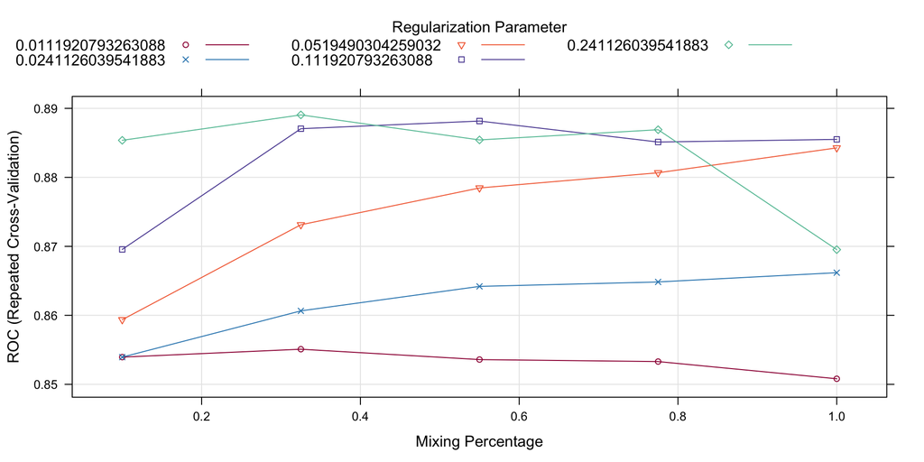

```r
fit_list[["Logistic Regression with Elastic Net Regularisation"]] <-
  train(casecontcd ~ ., data = training,
    method = "glmnet",
    family = "binomial",
    metric = "ROC",
    trControl = trCntrl,
    tuneLength = tune_length,
    NULL)

plot(fit_list[["Logistic Regression with Elastic Net Regularisation"]])
```

## Model: Random Forest with Selection by Univarite Filter

```r
rfSBF2 <- rfSBF
rfSBF2$score <- function(x, y)
  t.test(x ~ y)$p.value
rfSBF2$filter <- function (score, x, y)
  p.adjust(score, "BH") < 0.25  # less stringent criterion
rfSBF2$summary <- twoClassSummary

fit_list[["Random Forest with Selection by Univariate Filter"]] <-
  sbf(casecontcd ~ ., data = training,
    sbfControl = sbfControl(
      functions = rfSBF2,
      method = trCntrl$method,
      number = trCntrl$number,
      repeats = trCntrl$repeats,
      index = trCntrl$index))

print(fit_list[["Random Forest with Selection by Univariate Filter"]])
```

```
##
## Selection By Filter
##
## Outer resampling method: Cross-Validated (3 fold, repeated 5 times)
##
## Resampling performance:
##
##     ROC   Sens   Spec   ROCSD  SensSD  SpecSD
##  0.8596 0.9262 0.4858 0.02245 0.04314 0.07062
##
## Using the training set, 1566 variables were selected:
##    X100303123_TGI_at, X100125605_TGI_at, X100140461_TGI_at, X100141224_TGI_at, X100129538_TGI_at...
##
## During resampling, the top 5 selected variables (out of a possible 2659):
##    X100121670_TGI_at (100%), X100121844_TGI_at (100%), X100121953_TGI_at (100%), X100122306_TGI_at (100%), X100122724_TGI_at (100%)
##
## On average, 1012.7 variables were selected (min = 595, max = 1428)
```

# Compare models

Again, the performance as estimated by this cross-validation approach is most likely slightly over-optimistic. The reason is that the cross-validation folds not necessarily are disjoint at individual tumour level.

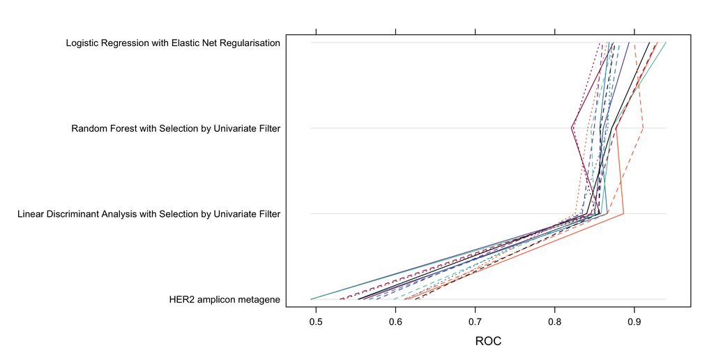

```r
resamps <- resamples(fit_list)
parallelplot(resamps, metric = "ROC")
```

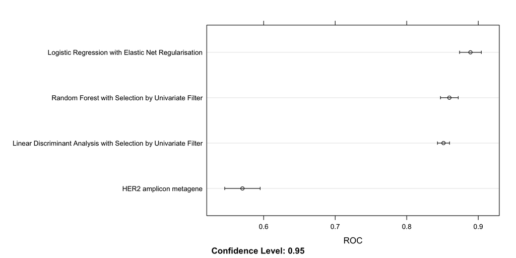

```r
dotplot(resamps, metric = "ROC")
```

See also http://topepo.github.io/caret/model-training-and-tuning.html#between-models

# Cache results

```r
save(testing, training, fit_list,
  file = file.path("..", "cache", "caret", "training.RData"))
```

© 2017 John Lövrot.  
This work is licensed under a [Creative Commons Attribution 4.0 International License](http://creativecommons.org/licenses/by/4.0/).  
The source code is available at github.com/lovrot/reproduce-cunha15canres.  
Version 0.0.0.9005